# Introduction to rasters with `terra`

### Statistics

We can use the same `summary()` command that is used in base R, to get a summary of the statistical information for an entire raster.

```r
summary(sst_cropped_masked)
```

```
#>    CRW_SST_2
#>  Min.   :19.82
#>  1st Qu.:24.25
#>  Median :25.05
#>  Mean   :25.19
#>  3rd Qu.:26.49
#>  Max.   :27.74
#>  NA's   :50850
```

These values are, for example, the mean value of all raster values, with NA values excluded.

To get individual statistical values, we need the function `global()`. For example to get the mean value of a raster:

```r
global(sst_cropped_masked, "mean", na.rm = TRUE)
```

```
#>               mean
#> CRW_SST_2 25.18745
```

We need to use `na.rm = TRUE` otherwise `NA` values are included and the mean is `NaN`. The object returned by `global` is a data frame, so if you want just the value, you need to do:

```r
sst_mean <- as.numeric(global(sst_cropped_masked, "mean", na.rm = TRUE))

sst_mean
```

```
#> [1] 25.18745
```

*`raster` users note*: `global()` replaces `cellStats()`, and the default is `na.rm = FALSE`, whereas the default for `cellStats()` was `na.rm = TRUE`.

### Classifying

We might want to break our raster values into groups. For example, we could say that all temperatures that are below the mean temperature are classified as “cooler” and all temperatures above the mean are “warmer”. We can do this using the `classify` function.

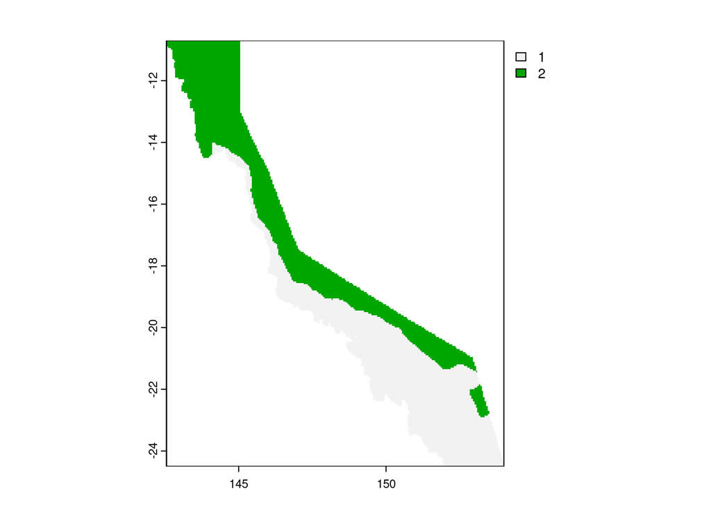

```r
#first we create a matrix that will be used for the classification
# all values >= 0 and less than the mean become 1
# all values greater than the mean become 2
reclass_matrix <- c(0, sst_mean, 1,
                    sst_mean, Inf, 2) |>
  matrix(ncol = 3, byrow = TRUE)

#now we classify our raster using this matrix
sst_reclassed <- classify(sst_cropped_masked, reclass_matrix)

#plot the result
plot(sst_reclassed)
```

A gut check tells us this looks right; the warmer areas are in the north, nearer to the equator.

This plot is ok, but it would be better if the colours were more appropriate and the legend gave some useful information.

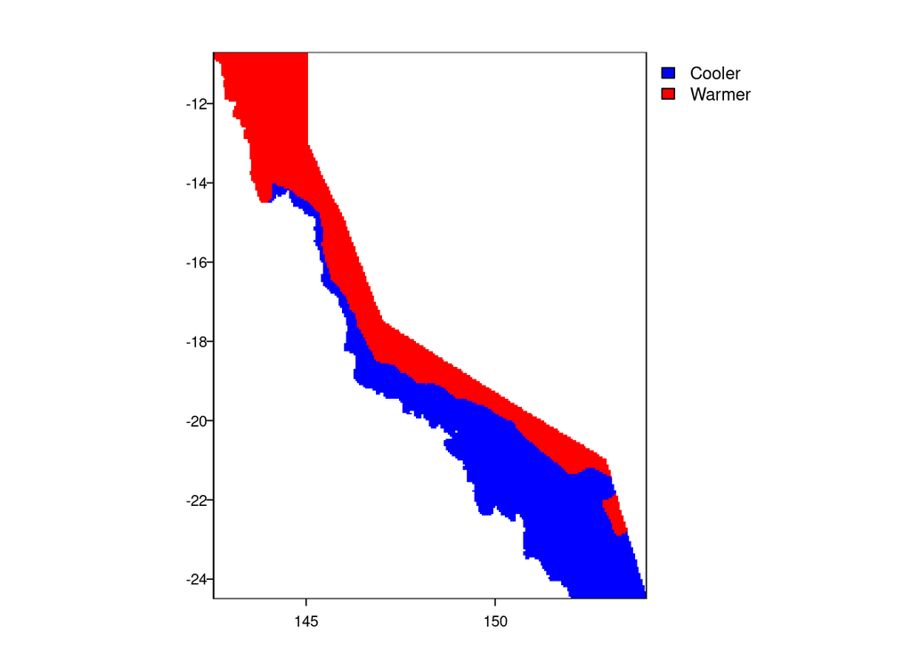

```r
plot(sst_reclassed, col = c("blue", "red"), plg = list(legend = c("Cooler", "Warmer")), las = 1) #the las = 1 argument just rotates the y-axis labels so that they are horizontal
```

### Raster math

The great thing about rasters are you can do maths with them! For example, doing `sst_reclassed + 1` just adds one to each raster value, and doing `sst_reclassed*2` multiplies each raster value by two.

As an example, lets convert our temperature data into Fahrenheit for our confused colleagues in the U.S. The conversion from Celsius to Fahrenheit is: Fahrenheit = (Celsius * 1.8) + 32.

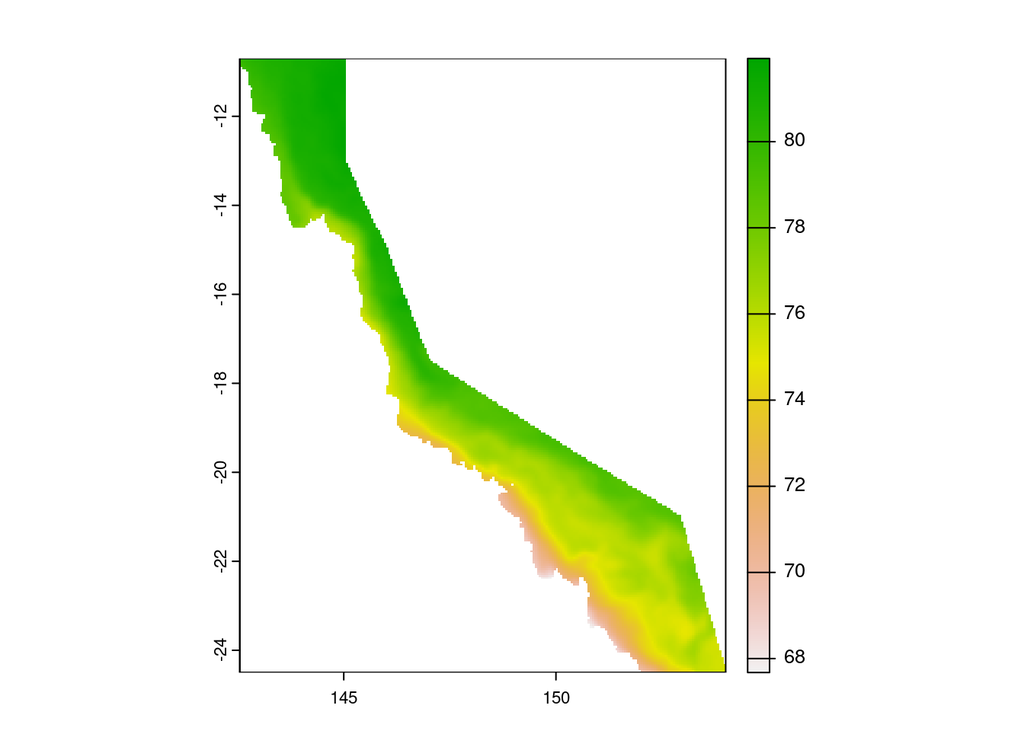

```r
#do the conversion
sst_fahrenheit <- (sst_cropped_masked*1.8) + 32

#plot our new raster
plot(sst_fahrenheit)
```

## Nice maps

Lets also make the map a bit prettier, choosing more appropriate colours and adding a scale bar

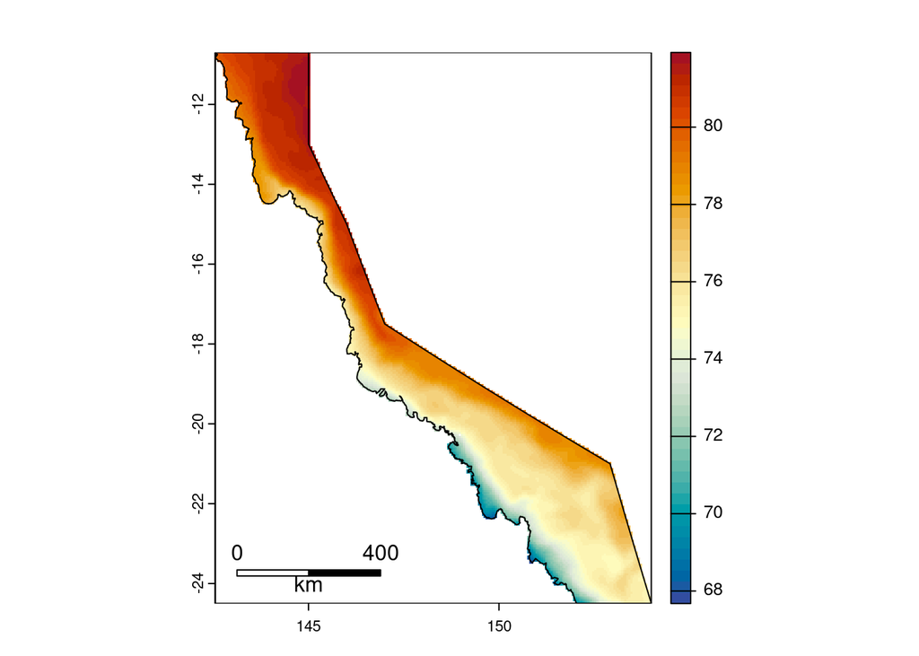

```r
plot(sst_fahrenheit, col = hcl.colors(50, palette = "RdYlBu", rev = TRUE)) #see ?hcl.colors for more info on colour palettes. rev= TRUE because we want to reverse the palette: red colours are the highest values and blue the lowest
lines(gbr_boundary)
sbar(d = 400, type = "bar", divs = 2, below = "km") #400km bar with 2 divisions and "km" written below
```